# Assignment 2 - Multiple Linear Regrassion

## Multiple Linear Regression Using Statmodels

#### Import lerquired library and API

```python
import statsmodels.api as sm
```

```python
import pandas as pd
```

#### Check the correct path and chnage the path to the file location and import the file

```python
import os
```

```python
os.getcwd()
```

```
'C:\\Users\\IBM_ADMIN'
```

```python
os.chdir(r'C:/Users/IBM_ADMIN/Music/UC/Module - Machine learning/Module 2/Assignment 2')
```

```python
asg=pd.read_csv('boston.csv')
```

#### Show head of the data set and describe the data set

```python
asg.head()
```

|  | CRIM | INDUS | NOX | RM | AGE | DIS | TAX | PT | B | MV |
| --- | --- | --- | --- | --- | --- | --- | --- | --- | --- | --- |
| 0 | 0.00632 | 2.31 | 0.538 | 6.575 | 65.199997 | 4.0900 | 296 | 15.300000 | 396.899994 | 24.000000 |
| 1 | 0.02731 | 7.07 | 0.469 | 6.421 | 78.900002 | 4.9671 | 242 | 17.799999 | 396.899994 | 21.600000 |
| 2 | 0.02729 | 7.07 | 0.469 | 7.185 | 61.099998 | 4.9671 | 242 | 17.799999 | 392.829987 | 34.700001 |
| 3 | 0.03237 | 2.18 | 0.458 | 6.998 | 45.799999 | 6.0622 | 222 | 18.700001 | 394.630005 | 33.400002 |
| 4 | 0.06905 | 2.18 | 0.458 | 7.147 | 54.200001 | 6.0622 | 222 | 18.700001 | 396.899994 | 36.200001 |

```python
asg.describe()
```

|  | CRIM | INDUS | NOX | RM | AGE | DIS | TAX | PT | B | MV |
| --- | --- | --- | --- | --- | --- | --- | --- | --- | --- | --- |
| count | 506.000000 | 506.000000 | 506.000000 | 506.000000 | 506.000000 | 506.000000 | 506.000000 | 506.000000 | 506.000000 | 506.000000 |
| mean | 3.613524 | 11.136779 | 0.554695 | 6.284634 | 68.574901 | 3.795043 | 408.237154 | 18.455534 | 356.674030 | 22.532806 |
| std | 8.601545 | 6.860353 | 0.115878 | 0.702617 | 28.148862 | 2.105710 | 168.537116 | 2.164946 | 91.294863 | 9.197104 |
| min | 0.006320 | 0.460000 | 0.385000 | 3.561000 | 2.900000 | 1.129600 | 187.000000 | 12.600000 | 0.320000 | 5.000000 |
| 25% | 0.082045 | 5.190000 | 0.449000 | 5.885500 | 45.025000 | 2.100175 | 279.000000 | 17.400000 | 375.377487 | 17.025000 |
| 50% | 0.256510 | 9.690000 | 0.538000 | 6.208500 | 77.500000 | 3.207450 | 330.000000 | 19.050000 | 391.440002 | 21.200001 |
| 75% | 3.677083 | 18.100000 | 0.624000 | 6.623500 | 94.074999 | 5.188425 | 666.000000 | 20.200001 | 396.225006 | 25.000000 |
| max | 88.976196 | 27.740000 | 0.871000 | 8.780000 | 100.000000 | 12.126500 | 711.000000 | 22.000000 | 396.899994 | 50.000000 |

#### Check if any NULL values exists in the data set

```python
asg.isnull().values.sum()
```

```
0
```

#### ploting the scatter plot matrix

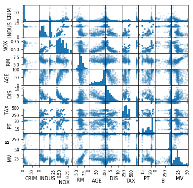

```python
#spm = pd.tools.plotting.scatter_matrix(df, alpha=0.2, figsize=(6, 6), diagonal='hist')
spm = pd.plotting.scatter_matrix(asg, alpha=0.2, figsize=(6, 6))
```

#### Devide the data set into Test and train data sets in 40:60 ratio

```python
from sklearn.model_selection import train_test_split
```

```python
X_train, X_test, Y_train, Y_test = train_test_split(asg.drop("MV", axis=1), asg['MV'], test_size = 0.4,\
                                                    random_state=112)
```

#### Add constant terms in Train data set

```python
X_train = sm.add_constant(X_train)
```

#### Fit the OLS model

```python
model1 = sm.OLS(Y_train, X_train)
```

```python
result = model1.fit()
```

#### Print model summary

```python
print(result.summary())
```

```
                            OLS Regression Results
==============================================================================
Dep. Variable:                     MV   R-squared:                       0.702
Model:                            OLS   Adj. R-squared:                  0.692
Method:                 Least Squares   F-statistic:                     76.54
Date:                Mon, 22 Oct 2018   Prob (F-statistic):           1.16e-71
Time:                        13:31:55   Log-Likelihood:                -922.37
No. Observations:                 303   AIC:                             1865.
Df Residuals:                     293   BIC:                             1902.
Df Model:                           9
Covariance Type:            nonrobust
==============================================================================
                 coef    std err          t      P>|t|      [0.025      0.975]
------------------------------------------------------------------------------
const         17.3165      6.407      2.703      0.007       4.707      29.926
CRIM          -0.1244      0.036     -3.477      0.001      -0.195      -0.054
INDUS         -0.1689      0.083     -2.034      0.043      -0.332      -0.005
NOX          -17.7667      5.230     -3.397      0.001     -28.059      -7.474
RM             6.6616      0.464     14.356      0.000       5.748       7.575
AGE           -0.0536      0.017     -3.151      0.002      -0.087      -0.020
DIS           -1.4583      0.261     -5.594      0.000      -1.971      -0.945
TAX            0.0004      0.003      0.141      0.888      -0.006       0.007
PT            -0.9689      0.166     -5.842      0.000      -1.295      -0.642
B              0.0069      0.004      1.868      0.063      -0.000       0.014
==============================================================================
Omnibus:                      205.031   Durbin-Watson:                   1.995
Prob(Omnibus):                  0.000   Jarque-Bera (JB):             3110.306
Skew:                           2.527   Prob(JB):                         0.00
Kurtosis:                      17.860   Cond. No.                     1.40e+04
==============================================================================

Warnings:
[1] Standard Errors assume that the covariance matrix of the errors is correctly specified.
[2] The condition number is large, 1.4e+04. This might indicate that there are
strong multicollinearity or other numerical problems.
```

```python
result.rsquared
```

```
0.7015881965860233
```

## Observation

-> From the model summary we can see that the parameters TAX and B is not significant at 5% significance level. Because p-values of the parameters (for TAX p-value is 0.888 and for B p-value is 0.063) are higher than 0.05 and confidence intervals for their co-efficient includes zeros .

-> On the other hand rest of the parameters are significant because their p-values are lower than 0.05.

Hence , we can conclude price of houses in Boston does not depends on TAX rate and B .

Let's try our inference and drop the column TAX 1st and the model again .

Note : If we can see the result we can see heteoscedasticity exixts between constant and parameter NOX . But constant term is not an actual parameter , this is y intercept . Hence I ignored heteoscedasticity .

```python
X_train = X_train.drop("TAX", axis=1)
```

```python
updated_model_result = sm.OLS(Y_train, X_train).fit()
```

```python
print(updated_model_result.summary())
```

```
                            OLS Regression Results
==============================================================================
Dep. Variable:                     MV   R-squared:                       0.702
Model:                            OLS   Adj. R-squared:                  0.693
Method:                 Least Squares   F-statistic:                     86.39
Date:                Mon, 22 Oct 2018   Prob (F-statistic):           1.22e-72
Time:                        13:32:11   Log-Likelihood:                -922.38
No. Observations:                 303   AIC:                             1863.
Df Residuals:                     294   BIC:                             1896.
Df Model:                           8
Covariance Type:            nonrobust
==============================================================================
                 coef    std err          t      P>|t|      [0.025      0.975]
------------------------------------------------------------------------------
const         17.1624      6.303      2.723      0.007       4.757      29.568
CRIM          -0.1225      0.033     -3.693      0.000      -0.188      -0.057
INDUS         -0.1640      0.075     -2.177      0.030      -0.312      -0.016
NOX          -17.5714      5.036     -3.489      0.001     -27.482      -7.661
RM             6.6686      0.461     14.480      0.000       5.762       7.575
AGE           -0.0537      0.017     -3.165      0.002      -0.087      -0.020
DIS           -1.4543      0.259     -5.622      0.000      -1.963      -0.945
PT            -0.9616      0.157     -6.114      0.000      -1.271      -0.652
B              0.0068      0.004      1.868      0.063      -0.000       0.014
==============================================================================
Omnibus:                      206.316   Durbin-Watson:                   1.995
Prob(Omnibus):                  0.000   Jarque-Bera (JB):             3161.342
Skew:                           2.546   Prob(JB):                         0.00
Kurtosis:                      17.983   Cond. No.                     9.09e+03
==============================================================================

Warnings:
[1] Standard Errors assume that the covariance matrix of the errors is correctly specified.
[2] The condition number is large, 9.09e+03. This might indicate that there are
strong multicollinearity or other numerical problems.
```

```python
updated_model_result.rsquared
```

```
0.7015678047772471
```

From the output we can see even though our R2 value ramins same our Adjusted R2 value slightly increased . This confirms that TAX is not significant in calculating price of houses in Boston and by keeping parameter TAX our Adjusted R2 value was penalized .  
In the next step we will drop the column B and run the model again .

```python
X_train1 = X_train.drop("B", axis=1)
```

```python
model_result1 = sm.OLS(Y_train, X_train1).fit()
```

```python
print(model_result1.summary())
```

```
                            OLS Regression Results
==============================================================================
Dep. Variable:                     MV   R-squared:                       0.698
Model:                            OLS   Adj. R-squared:                  0.691
Method:                 Least Squares   F-statistic:                     97.41
Date:                Mon, 22 Oct 2018   Prob (F-statistic):           6.63e-73
Time:                        13:34:21   Log-Likelihood:                -924.17
No. Observations:                 303   AIC:                             1864.
Df Residuals:                     295   BIC:                             1894.
Df Model:                           7
Covariance Type:            nonrobust
==============================================================================
                 coef    std err          t      P>|t|      [0.025      0.975]
------------------------------------------------------------------------------
const         20.4716      6.075      3.370      0.001       8.516      32.427
CRIM          -0.1368      0.032     -4.220      0.000      -0.201      -0.073
INDUS         -0.1783      0.075     -2.370      0.018      -0.326      -0.030
NOX          -18.9098      5.006     -3.778      0.000     -28.761      -9.059
RM             6.6754      0.462     14.434      0.000       5.765       7.586
AGE           -0.0529      0.017     -3.107      0.002      -0.086      -0.019
DIS           -1.4733      0.260     -5.676      0.000      -1.984      -0.962
PT            -0.9584      0.158     -6.069      0.000      -1.269      -0.648
==============================================================================
Omnibus:                      203.595   Durbin-Watson:                   1.992
Prob(Omnibus):                  0.000   Jarque-Bera (JB):             3088.247
Skew:                           2.501   Prob(JB):                         0.00
Kurtosis:                      17.818   Cond. No.                     1.82e+03
==============================================================================

Warnings:
[1] Standard Errors assume that the covariance matrix of the errors is correctly specified.
[2] The condition number is large, 1.82e+03. This might indicate that there are
strong multicollinearity or other numerical problems.
```

```python
model_result1.rsquared
```

```
0.6980254911724433
```

Now see the accuracy (R2) on the test set with the updated model .

```python
from sklearn.metrics import r2_score
```

```python
X_test = X_test.drop("TAX", axis=1)
```

```python
predictions = updated_model_result.predict(sm.add_constant(X_test))
```

```python
r2_score(Y_test, predictions)
```

```
0.5868353069410196
```